# Are Maryland Summers Getting Hotter Faster than they were in the Past

Skylar Mullin

#Background Info and Hypothesis

For my final project, I want to analyze data to see whether Maryland summers are warming at a faster rate than they were in the past. Climate change is an important topic, and I want to use data to see how it is affecting Maryland summers. I got the idea because I was sweating my ass off this summer.

My main hypothesis is that the average summer temperatures have increased since 1895 in Maryland. I want to further investigate whether the rate at which these temperatures are increasing has changed over time. The data I will be using for this analysis is from the National Oceanic and Atmospheric Administration (NOAA). I will analyze the data to search for potential upward trends.

#Data

The data from NOAA can be accessed here: https://www.ncei.noaa.gov/access/monitoring/climate-at-a-glance/statewide/time-series

For this project, I selected the state Maryland, a 3-month time period spanning from June to August, and a year range of 1895 to 2026 which is all the data the NOAA has. The data is aggregated statewide, not just individual weather stations. It is availible in CSV form below.

```r
library(tidyverse)
```

```r
climate_data <- read.csv("marylandsummers.csv", skip = 2)
```

```r
climate_data
```

| Date | Value |
| --- | --- |
| 189508 | 73.0 |
| 189608 | 73.2 |
| 189708 | 71.6 |
| 189808 | 74.7 |
| 189908 | 74.1 |
| 190008 | 75.5 |
| 190108 | 74.6 |
| 190208 | 72.2 |
| 190308 | 70.3 |
| 190408 | 71.4 |

[output cut: 122 more lines]

The data set has two columns: date and the average temperature. For my project on evaluating whether climate change is accelerating, I only need these two. In my project, I will most likely group the date by the years of 1895-1950, 1951-200, 2001-2026, so that I can analyze the acceleration.

#Further research

I plan to compare the different time period and create a visualization of the average summer temperatures and how they might have changed since 1895.

I could also potentially compare average nighttime and daytime temperatures to see whether one has increased faster than the other. I would need to download additional data from NOAA for this. I was trying to explore this option but was finding difficulty finding data on it. I don’t know if looking at the maximum temperature for the daytime, and the minimum temperature for the nighttime would have the same result? I went ahead and downloaded those csv’s below.

```r
daytime_high <- read.csv("summermax.csv", skip = 2)
```

```r
nighttime_low <- read.csv("summermin.csv", skip = 2)
```

Both also contain the same number of observations, meaning it marks the lowest and highest temperature for each summer. It also contains the two columns of date and temperature.

Going forward, the only question I have is if this is enough data for my analyses. Should I download the average, minimum, and maximum temperatures of each month instead?

#Changes after Feedback

The daytime and nighttime averages will be labeled as “average daily lows” and “average daily highs”.

My analysis will focus on rates of change, not just average differences.

#The Tests I could Run

The first thing I had to do before I ran any of my tests was properly name the column titles of my datasets. I discovered trying to run some of these that there was some extra heading. I tried to clean it up with “janitor” but then googled it and saw that I could just have R skip the first two rows so that the column headings were at the top. Now, both coloumns are clearly named Date and Value.

My starting point for this project would be to calculate the mean, median and standard deviation for each of the three time periods. These would give me baseline analysis of the general temperature trends and compare the different periods.

```r
climate_data <- climate_data |>
  mutate(year = floor(Date / 100), time_period = case_when(
year < 1938 ~ "early",
year < 1982 ~ "middle",
year < 2026 ~ "late"))

daytime_high <- daytime_high |>
  mutate( year = floor(Date / 100), time_period = case_when(
year < 1938 ~ "early",
year < 1982 ~ "middle",
year < 2026 ~ "late"))

nighttime_low <- nighttime_low |>
  mutate(year = floor(Date / 100), time_period = case_when(
year < 1938 ~ "early",
year < 1982 ~ "middle",
year < 2026 ~ "late"))
```

I had to add the “year = floor(date / 100),” because the average temperatures for the summer are recorded as “193808” because they were recorded in August each year. So I googled and used the floor to round down the year after it divides by 100, to get rid of the 08.

Now that they are grouped, I can start with the calculations.

```r
climate_data |>
  group_by(time_period) |>
  summarize(mean_temp = mean(Value, na.rm = TRUE), median_temp = median(Value, na.rm = TRUE), sd_temp = sd(Value, na.rm = TRUE))
```

| time_period | mean_temp | median_temp | sd_temp |
| --- | --- | --- | --- |
| early | 72.75116 | 72.90 | 1.321322 |
| late | 74.47273 | 74.40 | 1.357214 |
| middle | 73.04091 | 72.95 | 1.061004 |
| NA | 75.80000 | 75.80 | NA |

```r
daytime_high |>
  group_by(time_period) |>
  summarize(mean_temp = mean(Value, na.rm = TRUE), median_temp = median(Value, na.rm = TRUE), sd_temp = sd(Value, na.rm = TRUE))
```

| time_period | mean_temp | median_temp | sd_temp |
| --- | --- | --- | --- |
| early | 83.18140 | 83.10 | 1.657200 |
| late | 84.74773 | 84.95 | 1.616555 |
| middle | 83.73636 | 83.40 | 1.296344 |
| NA | 85.90000 | 85.90 | NA |

```r
nighttime_low |>
  group_by(time_period) |>
  summarize(mean_temp = mean(Value, na.rm = TRUE), median_temp = median(Value, na.rm = TRUE), sd_temp = sd(Value, na.rm = TRUE))
```

| time_period | mean_temp | median_temp | sd_temp |
| --- | --- | --- | --- |
| early | 62.30698 | 62.1 | 1.255350 |
| late | 64.17727 | 64.2 | 1.343176 |
| middle | 62.32955 | 62.1 | 1.103605 |
| NA | 65.70000 | 65.7 | NA |

Next, rate of change.

One of the most important parts of my project would be to calculate rates of change in temperature. I think regression will be another useful part of this analysis. I could create a scatter plot of the average summer temperatures per year, and add a regression line to show the relationship between the two. I could also break down each time period into a different scatterplot, to show the difference in slopes, which helps with my analysis on whether Maryland summers are warming faster than they were in the past.

I’ll start with the climate data, and do a scatterplot of all of it first.

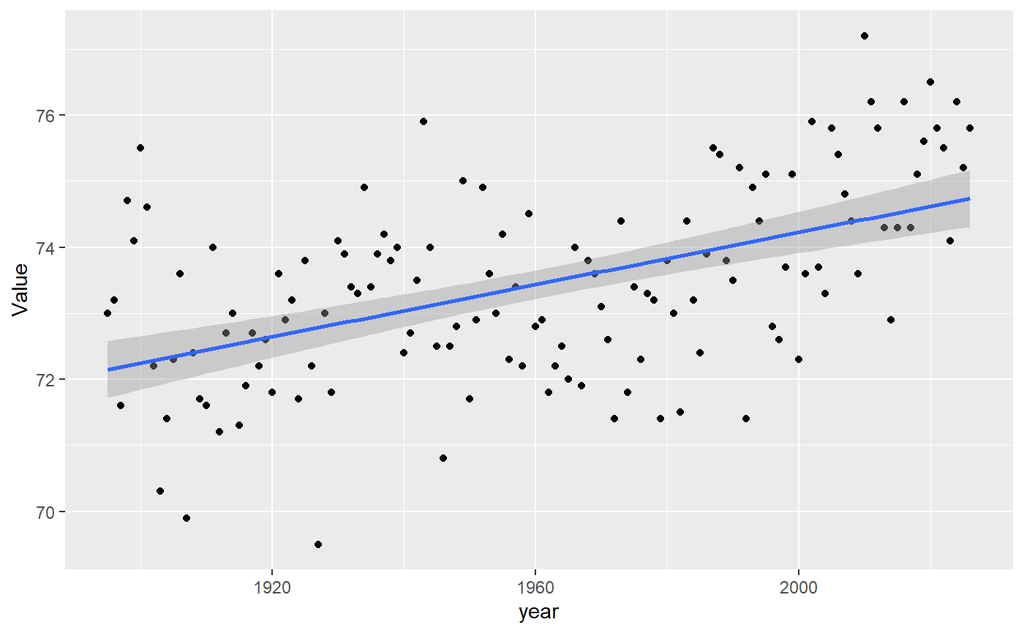

```r
climate_data |>
  ggplot() +
  geom_point(aes(x = year, y = Value)) +
  geom_smooth(aes(x = year, y = Value), method = "lm")
```

The graph seems to show that there is a positive linear relationship between the year and temperature.

Next I will separate it by time period to see if the relationship changes over time.

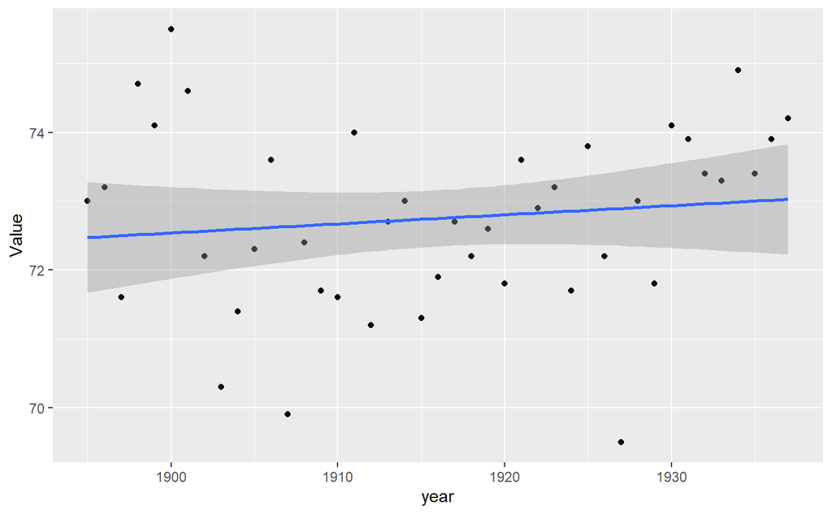

```r
climate_data |>
  filter(time_period == "early") |>
  ggplot() +
  geom_point(aes(x = year, y = Value)) +
  geom_smooth(aes(x = year, y = Value), method = "lm")
```

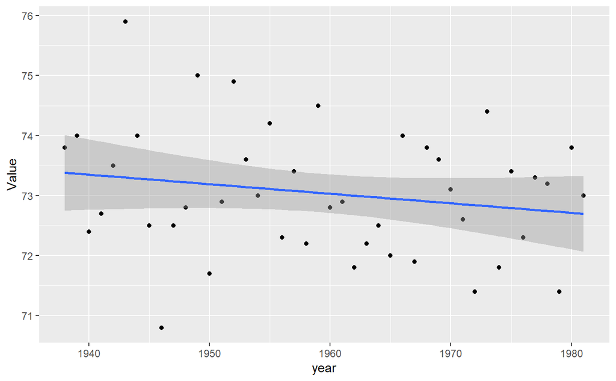

```r
climate_data |>
  filter(time_period == "middle") |>
  ggplot() +
  geom_point(aes(x = year, y = Value)) +
  geom_smooth(aes(x = year, y = Value), method = "lm")
```

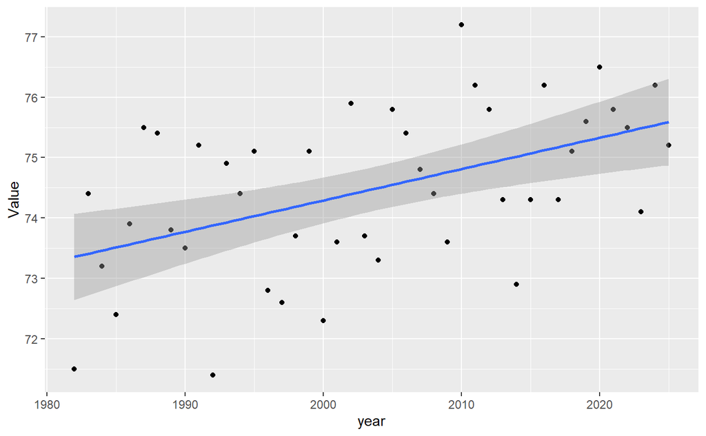

```r
climate_data |>
  filter(time_period == "late") |>
  ggplot() +
  geom_point(aes(x = year, y = Value)) +
  geom_smooth(aes(x = year, y = Value), method = "lm")
```

Another part of my analysis is comparing the average daily highs and average daily lows. I will use the same regression approach to compare their rates of change.

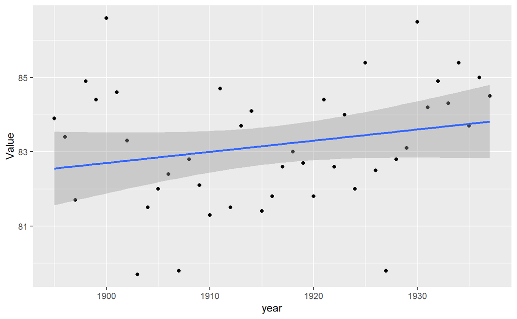

```r
daytime_high |>
  filter(time_period == "early") |>
  ggplot() +
  geom_point(aes(x = year, y = Value)) +
  geom_smooth(aes(x = year, y = Value), method = "lm")
```

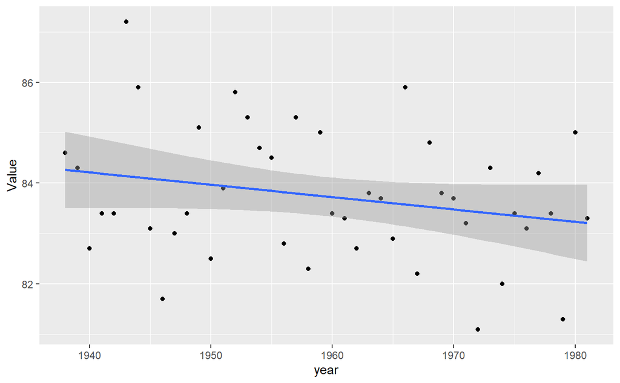

```r
daytime_high |>
  filter(time_period == "middle") |>
  ggplot() +
  geom_point(aes(x = year, y = Value)) +
  geom_smooth(aes(x = year, y = Value), method = "lm")
```

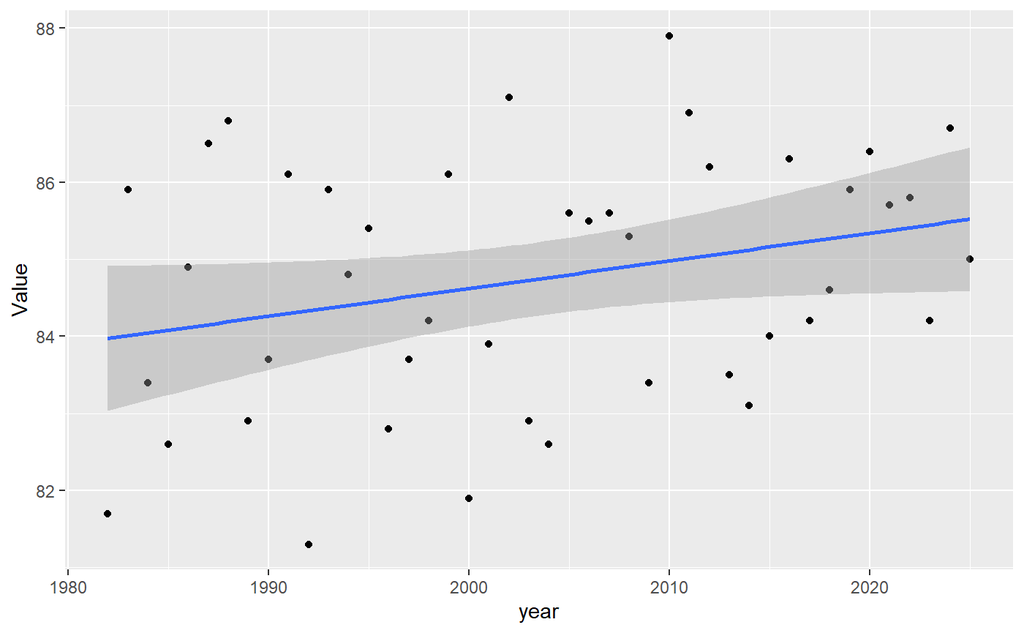

```r
daytime_high |>
  filter(time_period == "late") |>
  ggplot() +
  geom_point(aes(x = year, y = Value)) +
  geom_smooth(aes(x = year, y = Value), method = "lm")
```

And daily average lows:

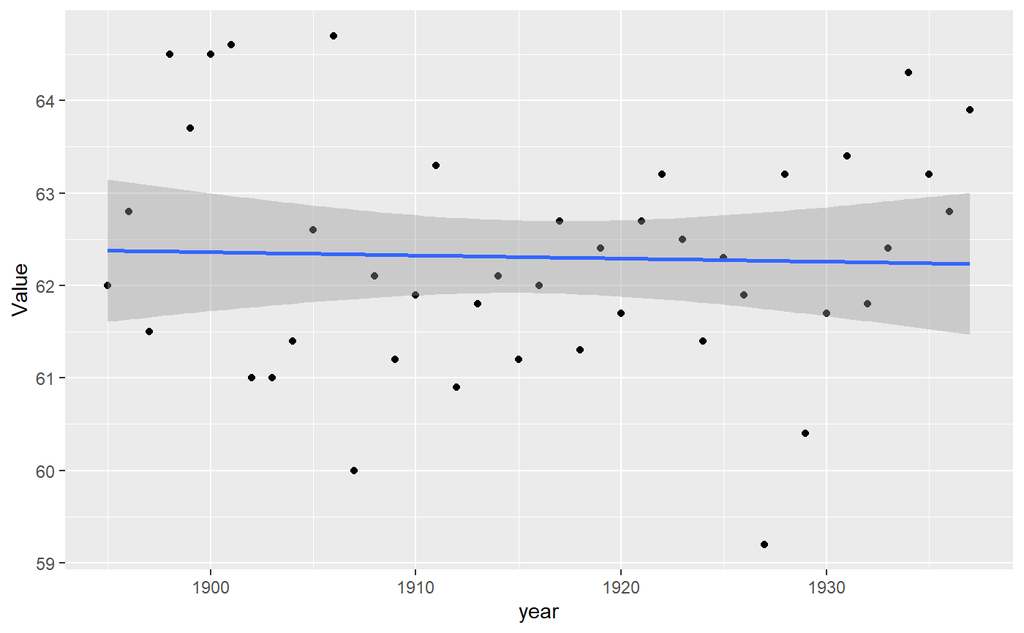

```r
nighttime_low |>
  filter(time_period == "early") |>
  ggplot() +
  geom_point(aes(x = year, y = Value)) +
  geom_smooth(aes(x = year, y = Value), method = "lm")
```

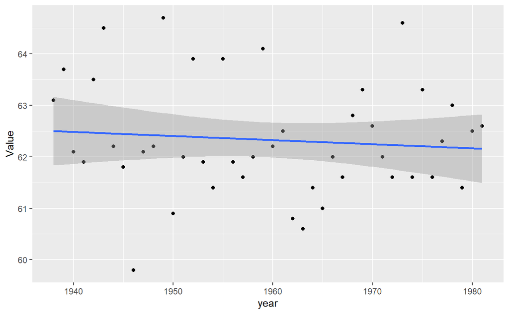

```r
nighttime_low |>
  filter(time_period == "middle") |>
  ggplot() +
  geom_point(aes(x = year, y = Value)) +
  geom_smooth(aes(x = year, y = Value), method = "lm")
```

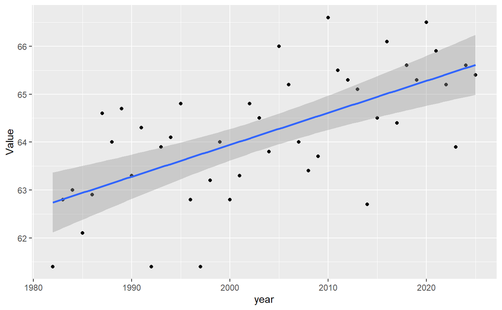

```r
nighttime_low |>
  filter(time_period == "late") |>
  ggplot() +
  geom_point(aes(x = year, y = Value)) +
  geom_smooth(aes(x = year, y = Value), method = "lm")
```

Altogether, I can compare these regression lines to see whether the warming has accelerated.

```r
t.test(
  Value ~ time_period,
  data = climate_data |>
    filter(time_period %in% c("early", "middle")))
```

```
    Welch Two Sample t-test

data:  Value by time_period
t = -1.1262, df = 80.419, p-value = 0.2634
alternative hypothesis: true difference in means between group early and group middle is not equal to 0
95 percent confidence interval:
 -0.8016852  0.2221926
sample estimates:
 mean in group early mean in group middle
            72.75116             73.04091
```

```r
t.test(
  Value ~ time_period,
  data = climate_data |>
    filter(time_period %in% c("middle", "late")))
```

```
    Welch Two Sample t-test

data:  Value by time_period
t = 5.5132, df = 81.266, p-value = 4.057e-07
alternative hypothesis: true difference in means between group late and group middle is not equal to 0
95 percent confidence interval:
 0.9151032 1.9485332
sample estimates:
  mean in group late mean in group middle
            74.47273             73.04091
```

```r
t.test(
  Value ~ time_period,
  data = climate_data |>
    filter(time_period %in% c("early", "late")))
```

```
    Welch Two Sample t-test

data:  Value by time_period
t = -5.9949, df = 84.999, p-value = 4.781e-08
alternative hypothesis: true difference in means between group early and group late is not equal to 0
95 percent confidence interval:
 -2.292535 -1.150594
sample estimates:
mean in group early  mean in group late
           72.75116            74.47273
```

While the first value doesn’t suggest any significance, the second two do. These suggest that Maryland summer temperatures have increased more in the most recent period.